# QRM Input 1 Noise

I am using the "Scope Acquisition" tutorial provided as a means of demonstrating an issue that we have identified on our QRM module's readout input number 1.

Most of the notebook below is unchanged from the tutorial provided by QBLOX, but I have added comments in several areas, which will always be preceded by "CSG:" in order to avoid any ambiguity.

## Setup

First, we are going to import the required packages.

```python
# Import ipython widgets
import json
import math
import os
import time

import ipywidgets as widgets
import matplotlib.pyplot
import numpy

# Set up the environment.
import scipy.signal
from scipy.fftpack import fft, fftshift
from IPython.display import display
from ipywidgets import fixed, interact, interact_manual, interactive

from qblox_instruments import Cluster, PlugAndPlay, Pulsar
```

#### Cluster QRM

```python
# close all previous connections to the cluster
Cluster.close_all()

cluster = Cluster("cluster", "192.168.2.2")
cluster.reset()

# time.sleep(0.5)

# # Run ADC calibration on QRM to deal with noisy input readings on Input 1
# cluster.start_adc_calib(4)

# time.sleep(0.5)

# qcm = cluster.module2
qrm = cluster.module4
# qcm_rf = cluster.module6

print(cluster.get_system_state())
```

```
Status: OKAY, Flags: NONE, Slot flags: NONE
```

## Generate waveforms

```python
# Waveform parameters
waveform_length = 120  # nanoseconds

# Waveform dictionary (data will hold the samples and index will be used to select the waveforms in the instrument).
waveforms = {
    "Gaussian": {
        "data": scipy.signal.gaussian(waveform_length, std=0.12 * waveform_length).tolist(),
        "index": 0,
    },
    "sine": {
        "data": [
            math.sin((2 * math.pi / waveform_length) * i)
            for i in range(0, waveform_length)
        ],
        "index": 1,
    },
}
```

Let's plot the waveforms to see what we have created.

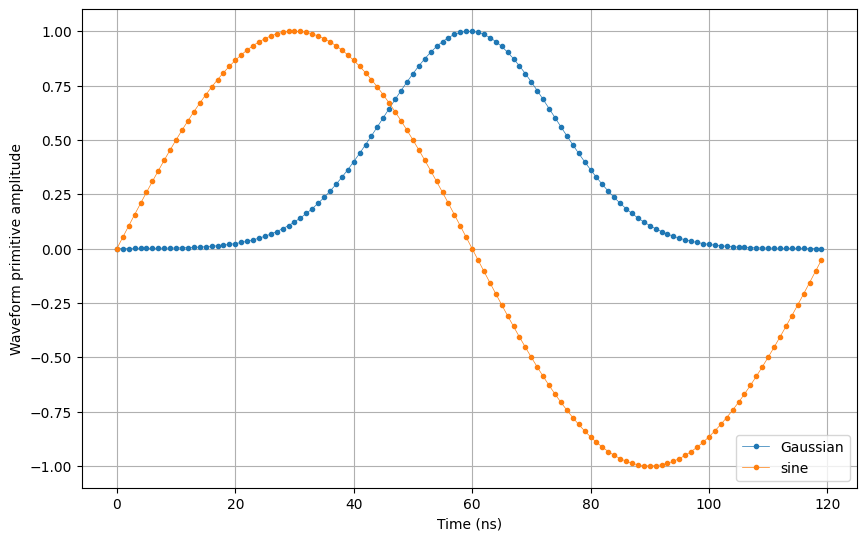

```python
time = numpy.arange(0, max(map(lambda d: len(d["data"]), waveforms.values())), 1)
fig, ax = matplotlib.pyplot.subplots(1, 1, figsize=(10, 10 / 1.61))

for wf, d in waveforms.items():
    ax.plot(time[: len(d["data"])], d["data"], ".-", linewidth=0.5, label=wf)

ax.legend(loc=4)
ax.yaxis.grid()
ax.xaxis.grid()
ax.set_ylabel("Waveform primitive amplitude")
ax.set_xlabel("Time (ns)")

matplotlib.pyplot.draw()
matplotlib.pyplot.show()
```

## Specify acquisitions

We also need to specify the acquisitions so that the instrument can allocate the required memory for it's acquisition list. In this case we will create 5 acquisition specifications that each create a single bin. However, we will not be using the bins in this turorial.

```python
# Acquisitions
acquisitions = {
    "single": {"num_bins": 1, "index": 0},
    "multiple_0": {"num_bins": 1, "index": 1},
    "multiple_1": {"num_bins": 1, "index": 2},
    "multiple_2": {"num_bins": 1, "index": 3},
    "avg": {"num_bins": 1, "index": 4},
}
```

## Create Q1ASM program

Now that we have the waveforms and acquisitions specification for the sequence, we need a simple Q1ASM program that sequences and acquires the waveforms.

```python
# Sequence program.
seq_prog = """
play    0,1,4     #Play waveforms and wait 4ns.
acquire 0,0,16380 #Acquire waveforms and wait remaining duration of scope acquisition.
stop              #Stop.
"""
```

## Upload sequence

Now that we have the waveform and acquisition specifications and Q1ASM program, we can combine them in a sequence stored in a JSON file.

```python
# Add sequence to single dictionary and write to JSON file.
sequence = {
    "waveforms": waveforms,
    "weights": {},
    "acquisitions": acquisitions,
    "program": seq_prog,
}
with open("scope_acquisition.json", "w", encoding="utf-8") as file:
    json.dump(sequence, file, indent=4)
    file.close()
```

Let's write the JSON file to the instruments. We will use sequencer 0, which will drive outputs $\text{O}^{[1-2]}$ and acquire on inputs $\text{I}^{[1-2]}$.

```python
# Upload sequence.
qrm.sequencer0.sequence("scope_acquisition.json")
```

## Play sequence

The sequence has been uploaded to the instrument. Now we need to configure the sequencers to trigger the acquisition with the `acquire` instruction.

```python
# Configure the sequencer to trigger the scope acquisition.
qrm.scope_acq_sequencer_select(0)
qrm.scope_acq_trigger_mode_path0("sequencer")
qrm.scope_acq_trigger_mode_path1("sequencer")

# Map sequencer to specific outputs (but first disable all sequencer connections)
for sequencer in qrm.sequencers:
    for out in range(0, 2):
        sequencer.set("channel_map_path{}_out{}_en".format(out % 2, out), False)
qrm.sequencer0.channel_map_path0_out0_en(True)
qrm.sequencer0.channel_map_path1_out1_en(True)
```

Now let's start the sequence.

```python
# Arm and start sequencer.
qrm.arm_sequencer(0)
qrm.start_sequencer()

# Print status of sequencer.
print("Status:")
print(qrm.get_sequencer_state(0))
```

```
Status:
Status: STOPPED, Flags: ACQ_SCOPE_DONE_PATH_0, ACQ_SCOPE_DONE_PATH_1, ACQ_BINNING_DONE
```

## Retrieve acquisition

The waveforms have now been sequenced on the outputs and acquired on the inputs. Lets make sure that the sequencer has finished it's acquisition and then retrieve the resulting data. The acquisition data is stored in a temporary memory in the instrument's FPGA. We need to first move the data from this memory into the into the instrument's acquisition list. From there we can retrieve it from the instrument.

```python
# Wait for the acquisition to finish with a timeout period of one minute.
qrm.get_acquisition_state(0, 1)

# Move acquisition data from temporary memory to acquisition list.
qrm.store_scope_acquisition(0, "single")

# Get acquisition list from instrument.
single_acq = qrm.get_acquisitions(0)
```

Let's plot the result.

CSG: This is our first indication that there is an issue with Input 1. There is a clear discrepancy between the plot below and the sample plots included on the "Read the Docs" page for the "Scope Acquisition" tutorial.

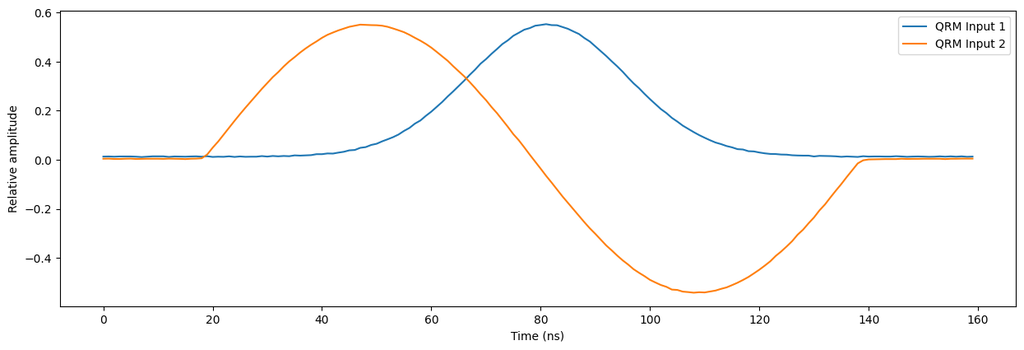

```python
# Plot acquired signal on both inputs.
fig, ax = matplotlib.pyplot.subplots(1, 1, figsize=(15, 15 / 2 / 1.61))
ax.plot(single_acq["single"]["acquisition"]["scope"]["path0"]["data"][130:290], label="QRM Input 1")
ax.plot(single_acq["single"]["acquisition"]["scope"]["path1"]["data"][130:290], label="QRM Input 2")
ax.set_xlabel("Time (ns)")
ax.set_ylabel("Relative amplitude")
matplotlib.pyplot.legend()
matplotlib.pyplot.show()
```

## Retrieve multiple acquisitions

We can also run the sequence multiple times consecutively and store the acquisition data in the instrument's acquisition list before retrieving them all in one go. To demonstrate this we will run the same sequence three times and vary the output gain for each run to create a clear distinction between the acquisitions.

```python
# First run
qrm.sequencer0.gain_awg_path0(0.33)
qrm.sequencer0.gain_awg_path1(0.33)

qrm.arm_sequencer(0)
qrm.start_sequencer()

qrm.get_acquisition_state(0, 1)

qrm.store_scope_acquisition(0, "multiple_0")

# Second run
qrm.sequencer0.gain_awg_path0(0.66)
qrm.sequencer0.gain_awg_path1(0.66)

qrm.arm_sequencer(0)
qrm.start_sequencer()

qrm.get_acquisition_state(0, 1)

qrm.store_scope_acquisition(0, "multiple_1")

# Second run
qrm.sequencer0.gain_awg_path0(1)
qrm.sequencer0.gain_awg_path1(1)

qrm.arm_sequencer(0)
qrm.start_sequencer()

qrm.get_acquisition_state(0, 1)

qrm.store_scope_acquisition(0, "multiple_2")

# Get acquisition list from instrument.
multiple_acq = qrm.get_acquisitions(0)
```

Let's plot the result again.

CSG: Again, and for a range of gain values, we see this apparent "noise" on Input channel 1. (Gaussian waveforms)

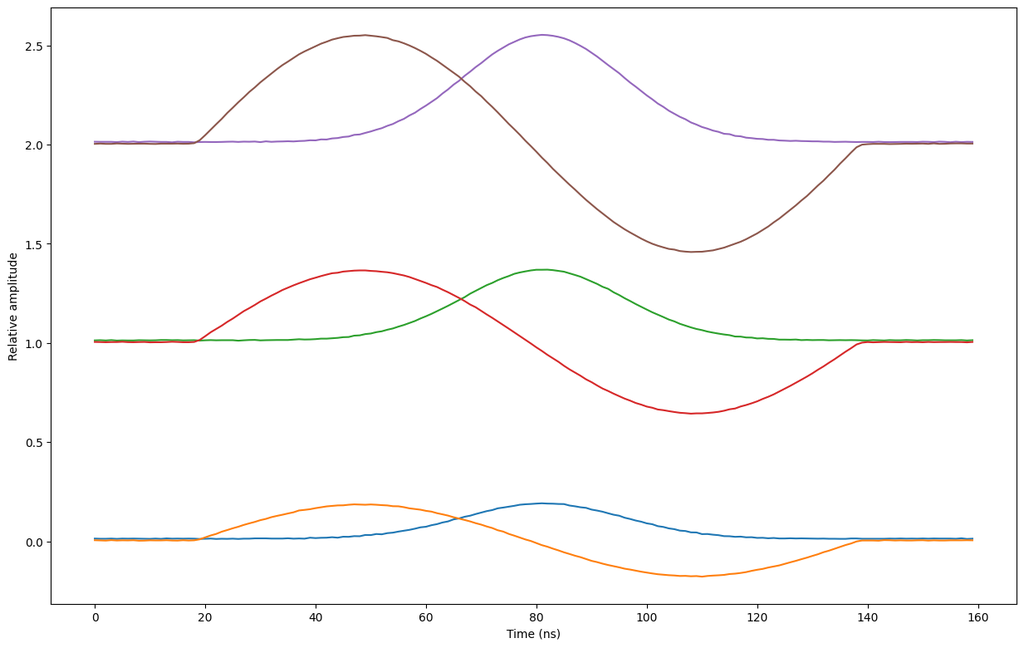

```python
# Plot acquired signals (add acquisition index to separate acquisitions in plot).
fig, ax = matplotlib.pyplot.subplots(1, 1, figsize=(15, 15 / 1.61))
for acq_idx in range(0, 3):
    ax.plot(
        numpy.array(
            multiple_acq["multiple_{}".format(acq_idx)]["acquisition"]["scope"][
                "path0"
            ]["data"][130:290]
        )
        + acq_idx
    )
    ax.plot(
        numpy.array(
            multiple_acq["multiple_{}".format(acq_idx)]["acquisition"]["scope"][
                "path1"
            ]["data"][130:290]
        )
        + acq_idx
    )
    ax.set_xlabel("Time (ns)")
    ax.set_ylabel("Relative amplitude")
matplotlib.pyplot.show()
```

## Hardware-based averaging

We can also use hardware in the instrument itself to automatically accumulate acquisition data on-the-fly. This can be used to do averaging, by dividing the final accumulated result by the number of accumulations. To use this feature, we first need to modify the Q1ASM to run the sequence multiple consecutive times.

```python
# Sequence program.
seq_prog = """
      move    1000,R0   #Loop iterator.

loop: play    0,1,4     #Play waveforms and wait 4ns.
      acquire 4,0,16380 #Acquire waveforms and wait remaining duration of scope acquisition.
      loop    R0,@loop  #Run until number of iterations is done.

      stop              #Stop.
"""
```

Next, we need to program, configure and start the sequencer. This time we will also configure the sequencer to run in averaging mode.

```python
# Add sequence to single dictionary and write to JSON file.
sequence = {
    "waveforms": waveforms,
    "weights": {},
    "acquisitions": acquisitions,
    "program": seq_prog,
}
with open("scope_acquisition_avg.json", "w", encoding="utf-8") as file:
    json.dump(sequence, file, indent=4)
    file.close()

# Upload sequence.
qrm.sequencer0.sequence("scope_acquisition_avg.json")

# Enable hardware averaging
qrm.scope_acq_avg_mode_en_path0(True)
qrm.scope_acq_avg_mode_en_path1(True)

# Arm and start sequencer.
qrm.arm_sequencer(0)
qrm.start_sequencer()

# Wait for sequence and acquisitions to finish.
qrm.get_acquisition_state(0, 1)

# Move accumulated result from temporary memory to the instrument's acquisition list.
qrm.store_scope_acquisition(0, "avg")

# Get acquisition list from instrument.
avg_acq = qrm.get_acquisitions(0)
```

The sequence has now run and accumulated a 1000 times. Time to finish the averaging process and print the result.

CSG: This was a bit of a surprise when we still believed there was some random noise affecting Input 1. It doesn't even seem to average away! This indicates to me that this is not a purely random process - some part of the active circuit when creating these waveforms is causing these systematic spikes.

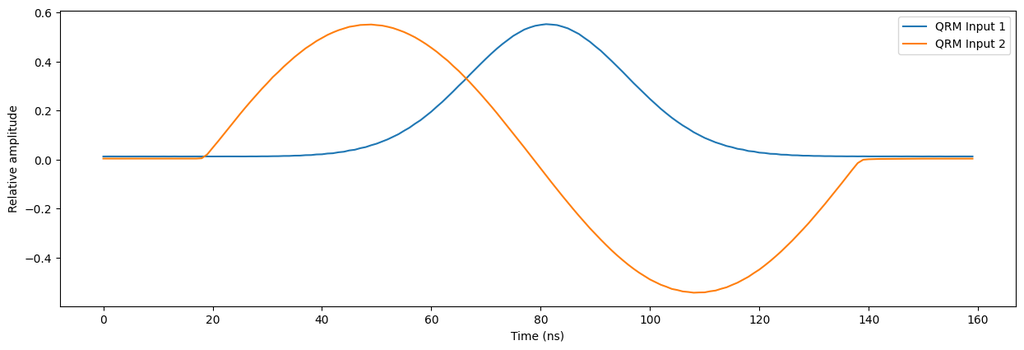

```python
# Plot results.
fig, ax = matplotlib.pyplot.subplots(1, 1, figsize=(15, 15 / 2 / 1.61))
ax.plot(numpy.array(avg_acq["avg"]["acquisition"]["scope"]["path0"]["data"][130:290]), label="QRM Input 1")
ax.plot(numpy.array(avg_acq["avg"]["acquisition"]["scope"]["path1"]["data"][130:290]), label="QRM Input 2")
ax.set_xlabel("Time (ns)")
ax.set_ylabel("Relative amplitude")
ax.legend()
matplotlib.pyplot.show()
```

Note that the accumulated acquisitions have already been averaged when the data is returned. The instrument keeps track of the number of accumulations and divides the result upon returning the data. The number of accumulations is also available for review.

```python
# Print number of averages
print(avg_acq["avg"]["acquisition"]["scope"]["path0"]["avg_cnt"])
print(avg_acq["avg"]["acquisition"]["scope"]["path1"]["avg_cnt"])
```

```
1000
1000
```

To show that the hardware averaging worked, let's compare and zoom in on the data from the very first acquisition in this tutorial and the very last.

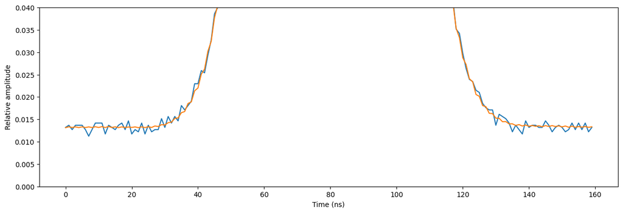

```python
# Plot results
fig, ax = matplotlib.pyplot.subplots(1, 1, figsize=(15, 15 / 2 / 1.61))
ax.plot(
    numpy.array(
        single_acq["single"]["acquisition"]["scope"]["path0"]["data"][130:290]
    ), label='First Acquisition'
)
ax.plot(numpy.array(avg_acq["avg"]["acquisition"]["scope"]["path0"]["data"][130:290]), label='Averaged Acquisition')
ax.set_xlabel("Time (ns)")
ax.set_ylabel("Relative amplitude")
ax.set_ylim(0.0,0.04)
matplotlib.pyplot.show()
```

CSG: The plot above confirms that indeed some parts of the Gaussian waveform are not being affected by random noise processes but rather highly reproducible ones. But below, we see how the noise on input channel 1 looks in a part of the readout that is not the active, Gaussian packet, and we see that the noise recorded (with variations of about 3mV) do get averaged away. By eye, it is hard to say whether the reduction follows the expected 1/sqrt(1000) reduction for 1000 runs, but it looks pretty close to me.

This then indicates to me that we do not see these reproducible noise spikes when the input module is just reading baseline noise floor on Input 1. That observation is confirmed when we observe how smooth and flat the sides of the Gaussian window look in the above plots.

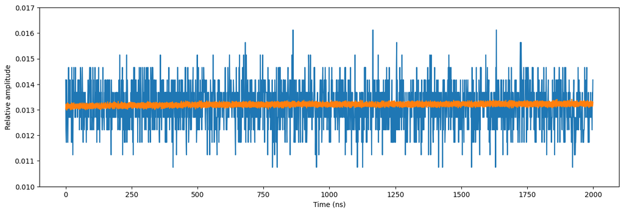

```python
# Plot results
fig, ax = matplotlib.pyplot.subplots(1, 1, figsize=(15, 15 / 2 / 1.61))
ax.plot(
    numpy.array(
        single_acq["single"]["acquisition"]["scope"]["path0"]["data"][1000:3000]
    ), label='First Acquisition'
)
ax.plot(numpy.array(avg_acq["avg"]["acquisition"]["scope"]["path0"]["data"][1000:3000]), label='Averaged Acquisition')
ax.set_xlabel("Time (ns)")
ax.set_ylabel("Relative amplitude")
ax.set_ylim(0.01,0.017)
matplotlib.pyplot.show()
```

CSG: By contrast, the sine wave (on Input 2), looks very clean. It is maybe a bit difficult to tell but the averaged waveform does look smoother than the initial waveform, as expected.

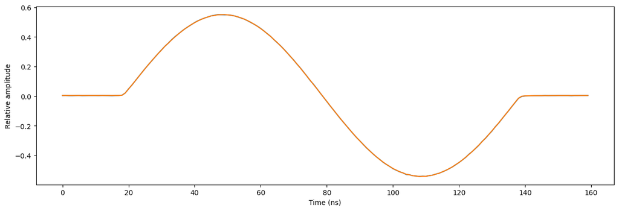

```python
# Plot results
fig, ax = matplotlib.pyplot.subplots(1, 1, figsize=(15, 15 / 2 / 1.61))
ax.plot(
    numpy.array(
        single_acq["single"]["acquisition"]["scope"]["path1"]["data"][130:290]
    ), label='First Acquisition'
)
ax.plot(numpy.array(avg_acq["avg"]["acquisition"]["scope"]["path1"]["data"][130:290]), label='Averaged Acquisition')
ax.set_xlabel("Time (ns)")
ax.set_ylabel("Relative amplitude")
# ax.set_ylim(0.5,0.58)
# ax.set_xlim(40,70)
matplotlib.pyplot.show()
```

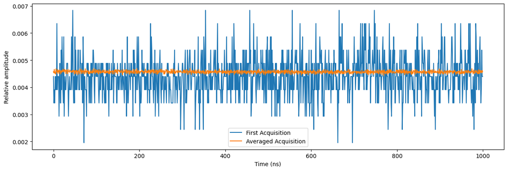

```python
# Plot results
fig, ax = matplotlib.pyplot.subplots(1, 1, figsize=(15, 15 / 2 / 1.61))
ax.plot(
    numpy.array(
        single_acq["single"]["acquisition"]["scope"]["path1"]["data"][1000:2000]
    ), label='First Acquisition'
)
ax.plot(numpy.array(avg_acq["avg"]["acquisition"]["scope"]["path1"]["data"][1000:2000]), label='Averaged Acquisition')
ax.set_xlabel("Time (ns)")
ax.set_ylabel("Relative amplitude")
matplotlib.pyplot.legend()
matplotlib.pyplot.show()
```

## Stop

Finally, let's stop the sequencers if they haven't already and close the instrument connection. One can also display a detailed snapshot containing the instrument parameters before closing the connection by uncommenting the corresponding lines.

```python
# Stop sequencer.
qrm.stop_sequencer()

# Print status of sequencer.
print(qrm.get_sequencer_state(0))
print()

# Uncomment the following to print an overview of the instrument parameters.
# Print an overview of the instrument parameters.
# print("Snapshot:")
# qrm.print_readable_snapshot(update=True)

# Close the instrument connection.
Pulsar.close_all()
Cluster.close_all()
```

```
Status: STOPPED, Flags: FORCED_STOP, ACQ_SCOPE_DONE_PATH_0, ACQ_SCOPE_OVERWRITTEN_PATH_0, ACQ_SCOPE_DONE_PATH_1, ACQ_SCOPE_OVERWRITTEN_PATH_1, ACQ_BINNING_DONE
```